# Percentage_ICU_prediction

## Percentage ICU bed availability prediction in state of Illinois

#### Author: Yilin Xu

#### Date: July 21,2021

#### Introduction:

Since the COVID-19 breakout, the healthcare system in Illinois is under tremendous pressure to satisfy the increased need for COVID-19 treatment. The Delta variant of the coronavirus has been spreading rapidly throughout the US and the world. This variant is highly transmissible and more virulent. It's critical to prepare sufficient medical supplies to meet patients needs, such as ICU beds and ventilators. In this notebook, we construct an Hierarchical Bayesian Binomial Regression model, a Univariate/Multivariate LSTM model and a Univariate/Multivariate CNN-LSTM model forecasting the percentage of ICU bed availability for the next 14 days

#### Set up notebook

```python
%reload_ext autoreload
%autoreload 2
%matplotlib inline
import warnings
warnings.filterwarnings('ignore')
```

```python
#!pip install wget
#!pip install pymc3
#!pip install mkl
#!conda install -c conda-forge python-graphviz -y
#!pip install geopandas
#!pip install pyarrow
#!pip install --upgrade google-cloud-bigquery
#!pip install tensorflow
#!pip install keras
#!pip install tensorflow --upgrade --force-reinstall
import wget
import pandas as pd
import numpy as np
import json
import os
import math
import requests
import re
import matplotlib.pyplot as plt
import seaborn as sns
import pymc3 as pm
import arviz as az
from sklearn.model_selection import train_test_split
from urllib.parse import quote
from google.cloud import bigquery
from sklearn import preprocessing
from sklearn.metrics import mean_squared_error
from sklearn.metrics import r2_score
from sklearn.linear_model import Lasso
from keras.models import Sequential
from keras.layers import LSTM
from keras.layers import Dense
from keras.layers import Dropout
from keras.layers import Conv1D, MaxPooling1D, Flatten, RepeatVector, TimeDistributed
from statsmodels.stats.proportion import proportion_confint
from sklearn.model_selection import TimeSeriesSplit
from statsmodels.tsa.seasonal import seasonal_decompose
from pandas.plotting import autocorrelation_plot
from statsmodels.tsa.stattools import kpss
import matplotlib.patches as mpatches

# Setup the Google application credential
os.environ["GOOGLE_APPLICATION_CREDENTIALS"]="steady-monitor-310002-1ba425d14288.json"
# Create Client object for query purpose
client = bigquery.Client()
```

```
WARNING (theano.link.c.cmodule): install mkl with `conda install mkl-service`: No module named 'mkl'
```

#### Google Mobility Data for Illinios

```python
# Query county level daily mobility data from Google Mobility data table
il_mobility_sql = """
  SELECT
  country_region_code,
  sub_region_1,
  date,
  retail_and_recreation_percent_change_from_baseline as recreation,
  grocery_and_pharmacy_percent_change_from_baseline as grocery,
  parks_percent_change_from_baseline as parks,
  transit_stations_percent_change_from_baseline as transit,
  workplaces_percent_change_from_baseline as workplaces,
  residential_percent_change_from_baseline as residential,
  FROM `bigquery-public-data.covid19_google_mobility.mobility_report`
  WHERE
    country_region_code = 'US' AND
    sub_region_1 = "Illinois" AND
    census_fips_code is not null
"""
query_mobility_job = client.query(il_mobility_sql)
il_mobility_df = query_mobility_job.to_dataframe()
il_mobility_df.fillna(0, inplace=True)
il_mobility_df['date'] = pd.to_datetime(il_mobility_df['date'])
columns = ['sub_region_1','date','recreation','grocery','parks','transit','workplaces','residential']
il_mobility_df = il_mobility_df[columns]
il_mobility_df = il_mobility_df.groupby('date').agg({'recreation':'mean','grocery':'mean','parks':'mean','transit':'mean', \
     'workplaces':'mean','residential':'mean'})
```

```python
il_mobility_df.shape
```

```
(541, 6)
```

```python
il_mobility_df.tail()
```

| date | recreation | grocery | parks | transit | workplaces | residential |
| --- | --- | --- | --- | --- | --- | --- |
| 2021-08-04 | 6.989583 | 6.208333 | 11.354167 | 3.583333 | -24.760417 | 2.427083 |
| 2021-08-05 | 6.760417 | 6.697917 | 13.583333 | 4.322917 | -25.093750 | 2.250000 |
| 2021-08-06 | 3.583333 | 3.802083 | 11.645833 | 4.854167 | -26.187500 | 2.187500 |
| 2021-08-07 | 4.177215 | 6.835443 | 19.164557 | 9.278481 | -11.113924 | -0.911392 |
| 2021-08-08 | 7.161765 | 6.220588 | 22.411765 | 9.617647 | -12.823529 | -0.382353 |

#### COVID Case for Illinois from covid19_open_data

```python
# Query for data description in google mobility data
il_case_sql="""
SELECT
    province_state,
    country_region,
    date,
    confirmed,
    deaths,
    recovered,
    fips,
    admin_2
FROM
  `bigquery-public-data.covid19_open_data.compatibility_view`
WHERE
    province_state="Illinois"
ORDER BY
    fips,date
  """

il_case_job = client.query(il_case_sql)
il_case_df = il_case_job.to_dataframe()
il_case_df.fillna(0, inplace=True)
il_case_df.head()
columns = ['date','confirmed','deaths']
il_case_df = il_case_df[columns]
il_case_df['date'] = pd.to_datetime(il_case_df['date'])
il_case_df = il_case_df.groupby('date').agg({'confirmed':'sum','deaths':'sum'})
il_case_df.shape
```

```
(591, 2)
```

Since the confirmed cases and deaths are cumulative, we will transform them into daily case and death incidence.

```python
il_case_df['confirmed_last_day'] = il_case_df['confirmed'].shift(1)
while any(il_case_df['confirmed']<il_case_df['confirmed_last_day']):
    il_case_df['confirmed'] = il_case_df.apply(lambda x: max(x['confirmed'],x['confirmed_last_day']),axis = 1)
il_case_df['confirmed_per_day'] = il_case_df['confirmed'] - il_case_df['confirmed_last_day']
il_case_df['deaths_last_day'] = il_case_df['deaths'].shift(1)
while any(il_case_df['deaths']<il_case_df['deaths_last_day']):
    il_case_df['deaths'] = il_case_df.apply(lambda x: max(x['deaths'],x['deaths_last_day']),axis = 1)
il_case_df['deaths_per_day'] = il_case_df['deaths'] - il_case_df['deaths_last_day']
il_case_df = il_case_df.drop(columns = ['confirmed','confirmed_last_day','deaths','deaths_last_day'])
il_case_df = il_case_df.dropna()
il_case_df.rename(columns = {'confirmed_per_day':'confirmed','deaths_per_day':'deaths'},inplace=True)
```

```python
il_case_df.head()
```

| date | confirmed | deaths |
| --- | --- | --- |
| 2020-01-02 | 0.0 | 0.0 |
| 2020-01-03 | 0.0 | 0.0 |
| 2020-01-04 | 0.0 | 0.0 |
| 2020-01-05 | 0.0 | 0.0 |
| 2020-01-06 | 0.0 | 0.0 |

#### Resurgence Data for Illinois from IDPH

```python
il_resurgence_df = pd.read_csv('https://idph.illinois.gov/DPHPublicInformation/api/COVIDExport/GetResurgenceData?format=csv', skiprows=1)
il_resurgence_df['ReportDate'] = pd.to_datetime(il_resurgence_df['ReportDate'])
il_resurgence_df.head()
columns = ['ReportDate','RegionDescription','ICUAvailPct_Avg','CLIAdmissions_RollingAvg']
il_resurgence_df = il_resurgence_df[columns]
il_resurgence_df = il_resurgence_df[il_resurgence_df.RegionDescription != 'East-Central (Excluding UIUC Saliva Tests)']
il_resurgence_df.shape
```

```
(4642, 4)
```

```python
ICU_total = {'North':181,'North-Central':249,'West-Central':165,'Metro East':108,'Southern':89,'East-Central':143, \
             'South Suburban':146,'West Suburban':344,'North Suburban':172,'Suburban Cook':695,'Chicago':884}
```

```python
il_resurgence_df['ICUAvailPct_Avg'] = il_resurgence_df['ICUAvailPct_Avg'].apply(lambda x: float(x.strip('%'))/100.0)
```

```python
il_resurgence_df.head()
```

|  | ReportDate | RegionDescription | ICUAvailPct_Avg | CLIAdmissions_RollingAvg |
| --- | --- | --- | --- | --- |
| 0 | 2020-06-13 | North | 0.53 | 2 |
| 1 | 2020-06-13 | North-Central | 0.49 | 2 |
| 2 | 2020-06-13 | West-Central | 0.55 | 1 |
| 3 | 2020-06-13 | Metro East | 0.48 | 4 |
| 4 | 2020-06-13 | Southern | 0.59 | 1 |

```python
il_resurgence_df['ICUAvail'] = il_resurgence_df.replace(ICU_total)['RegionDescription'].astype(int)*il_resurgence_df['ICUAvailPct_Avg']
```

```python
il_resurgence_df = il_resurgence_df.groupby('ReportDate').agg({'ICUAvail':sum,'CLIAdmissions_RollingAvg':sum})
il_resurgence_df['ICUAvail'] = np.floor(il_resurgence_df['ICUAvail']).astype(int)
```

```python
il_resurgence_df.head()
```

| ReportDate | ICUAvail | CLIAdmissions_RollingAvg |
| --- | --- | --- |
| 2020-06-13 | 1402 | 70 |
| 2020-06-14 | 1444 | 85 |
| 2020-06-15 | 1505 | 103 |
| 2020-06-16 | 1501 | 121 |
| 2020-06-17 | 1455 | 119 |

#### Merge Tables

il_mobility_df, il_case_df, il_resurgence_df

```python
# Merge mobility dataframe with case/death dataframe by county and date, keep all rows in mobility dataframe
mobility_case = pd.merge(il_mobility_df, il_case_df,  how='inner', left_on=['date'], right_on = ['date'])
mobility_case.head()
```

| date | recreation | grocery | parks | transit | workplaces | residential | confirmed | deaths |
| --- | --- | --- | --- | --- | --- | --- | --- | --- |
| 2020-02-15 | 6.209302 | 2.534884 | 3.418605 | 0.720930 | 1.220930 | -0.220930 | 0.0 | 0.0 |
| 2020-02-16 | 9.542169 | 3.253012 | 4.084337 | 0.927711 | 1.554217 | -0.325301 | 0.0 | 0.0 |
| 2020-02-17 | -0.431579 | -2.926316 | -1.957895 | -1.389474 | -20.894737 | 2.463158 | 0.0 | 0.0 |
| 2020-02-18 | 0.425532 | -1.117021 | 0.723404 | 0.563830 | 1.351064 | 0.148936 | 0.0 | 0.0 |
| 2020-02-19 | 2.127660 | -1.691489 | 0.510638 | 0.914894 | 1.765957 | 0.031915 | 0.0 | 0.0 |

```python
# Merge mobility_case dataframe with il_resurgence_df
mobility_case_resurgence= pd.merge(mobility_case, il_resurgence_df, how='right', left_index=True, right_on = ['ReportDate'])
mobility_case_resurgence['ICUAvailPctAvg'] = mobility_case_resurgence['ICUAvail']/3176
mobility_case_resurgence.drop(columns=['ICUAvail'],inplace=True)
mobility_case_resurgence.tail()
```

| ReportDate | recreation | grocery | parks | transit | workplaces | residential | confirmed | deaths | CLIAdmissions_RollingAvg | ICUAvailPctAvg |
| --- | --- | --- | --- | --- | --- | --- | --- | --- | --- | --- |
| 2021-08-04 | 6.989583 | 6.208333 | 11.354167 | 3.583333 | -24.760417 | 2.427083 | 2968.0 | 17.0 | 146 | 0.232368 |
| 2021-08-05 | 6.760417 | 6.697917 | 13.583333 | 4.322917 | -25.093750 | 2.250000 | 3192.0 | 14.0 | 155 | 0.231423 |
| 2021-08-06 | 3.583333 | 3.802083 | 11.645833 | 4.854167 | -26.187500 | 2.187500 | 2976.0 | 13.0 | 156 | 0.230793 |
| 2021-08-07 | 4.177215 | 6.835443 | 19.164557 | 9.278481 | -11.113924 | -0.911392 | 28.0 | 0.0 | 165 | 0.223866 |
| 2021-08-08 | 7.161765 | 6.220588 | 22.411765 | 9.617647 | -12.823529 | -0.382353 | 0.0 | 0.0 | 174 | 0.215995 |

```python
mobility_case_resurgence.shape
merged_dataset =  mobility_case_resurgence.copy()
```

```python
merged_dataset.columns
```

```
Index(['recreation', 'grocery', 'parks', 'transit', 'workplaces',
       'residential', 'confirmed', 'deaths', 'CLIAdmissions_RollingAvg',
       'ICUAvailPctAvg'],
      dtype='object')
```

We would like to predict the ICU bed availabity in 14 days.

```python
mobility_case_resurgence['ICUAvail_14'] = mobility_case_resurgence['ICUAvailPctAvg'].shift(-14)
mobility_case_resurgence.dropna(inplace=True)
mobility_case_resurgence['ICUAvail_14'] = mobility_case_resurgence['ICUAvail_14']
```

Based on ICUAvailPct_Avg, as of 100 ICU bed per specific county, available ICU bed would be ICUAvailPct_Avg * 100

```python
mobility_case_resurgence['available_icu'] = mobility_case_resurgence['ICUAvail_14']*100
mobility_case_resurgence['available_icu'] = mobility_case_resurgence['available_icu'].apply(np.floor).apply(int)
data = mobility_case_resurgence.drop(['ICUAvail_14'],axis=1)
data.tail()
```

| ReportDate | recreation | grocery | parks | transit | workplaces | residential | confirmed | deaths | CLIAdmissions_RollingAvg | ICUAvailPctAvg | available_icu |
| --- | --- | --- | --- | --- | --- | --- | --- | --- | --- | --- | --- |
| 2021-07-21 | 6.458333 | 5.322917 | 11.552083 | 3.843750 | -24.750000 | 2.375000 | 1301.0 | 5.0 | 77 | 0.236461 | 23 |
| 2021-07-22 | 7.468750 | 6.114583 | 14.114583 | 3.937500 | -25.218750 | 2.250000 | 1886.0 | 5.0 | 81 | 0.236776 | 23 |
| 2021-07-23 | 4.400000 | 3.136842 | 14.400000 | 5.452632 | -26.273684 | 2.052632 | 1341.0 | 2.0 | 85 | 0.237720 | 23 |
| 2021-07-24 | 4.602564 | 6.730769 | 18.910256 | 8.717949 | -10.153846 | -0.756410 | 0.0 | 0.0 | 88 | 0.238350 | 22 |
| 2021-07-25 | 8.400000 | 5.971429 | 22.528571 | 10.200000 | -12.142857 | -0.728571 | 0.0 | 0.0 | 93 | 0.235516 | 21 |

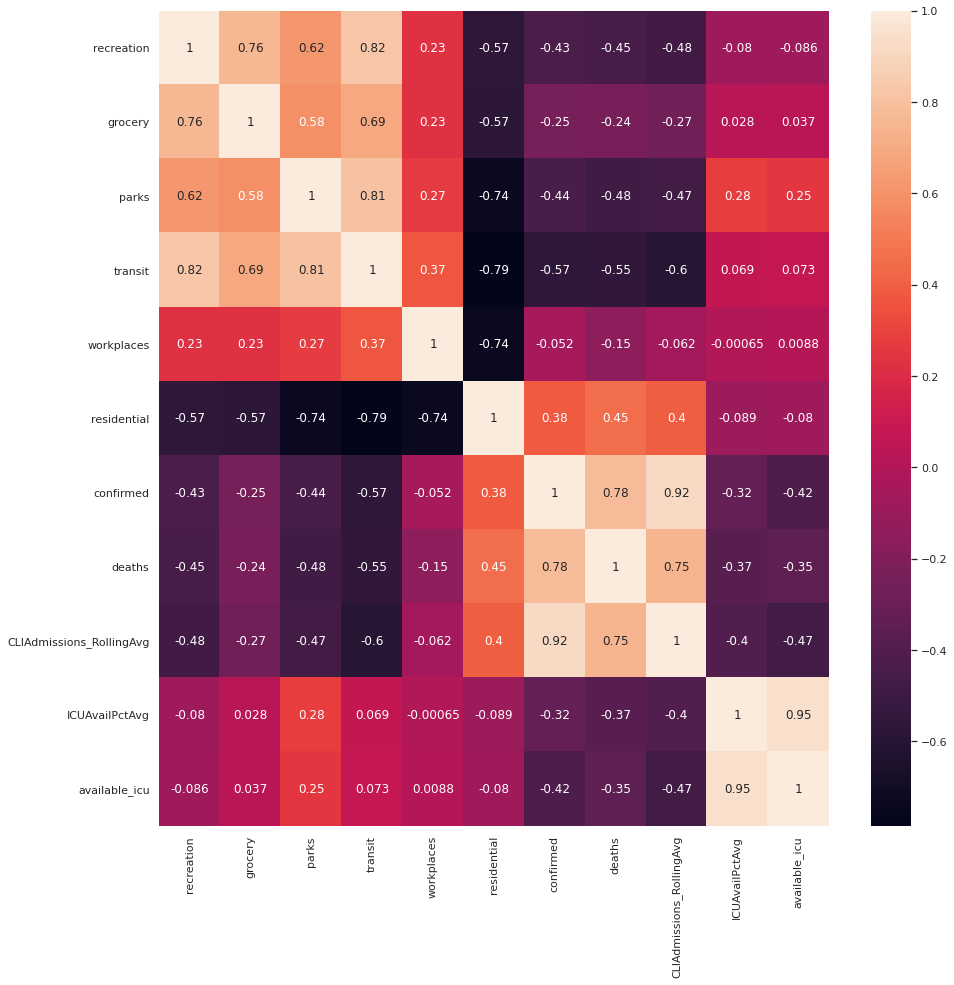

```python
sns.set(rc={'figure.figsize':(15,15)})
corr = data.corr()
sns.heatmap(corr,
        xticklabels=corr.columns,
        yticklabels=corr.columns,
            annot=True
        )
```

ICU Availibility rate is negatively correlated with residential,confirmed, deaths and CLIAdmission_RollingAvg, while positively correlated with parks,transit mobility and ICUAvail. The non-correlated features were droped.

```python
data = data.drop(columns=['recreation','grocery','workplaces'])
```

#### Split into train and test

```python
X = data.drop(columns = ['available_icu'])
y = data.available_icu
```

```python
# gen train & test sets
X_train, X_test, y_train, y_test = train_test_split(X, y, test_size=0.2, random_state=123)
```

```python
# normalize data (using train data only)

scaler = preprocessing.StandardScaler()
standard_data = scaler.fit_transform(X_train)
x_scaled = pd.DataFrame(standard_data, columns=X_train.columns,index=X_train.index)

x_means = scaler.mean_
print('x_means:\n', x_means)
x_scales = scaler.scale_
print('\nx_scales:\n', x_scales)

# append intercept
x_scaled.insert(0, 'Intercept', 1)

print()
print(x_scaled.shape)
```

```
x_means:
 [ 7.47570419e+00 -1.59552508e+00  3.20923570e+00  3.06372086e+03
  4.64785276e+01  1.86331288e+02  3.08388450e-01]

x_scales:
 [9.18702731e+00 4.94089946e+00 2.48525520e+00 3.12005379e+03
 5.32653201e+01 1.25533734e+02 8.42206402e-02]

(326, 8)
```

#### Binomial Regression with PyMC

Define the hierarchical binomial regression model in PyMC3:

```python
"""
Shrink the Beta toward 0 by setting sigmaBeta prior of Gamma distribution
with relatively low mode mode = (alpha-1)/beta = 1
"""
n=100
with pm.Model() as binomreg_model:
    X_data = pm.Data("X_data",x_scaled)
    sigmaBeta = pm.Gamma('sigmaBeta',2.3,1.3,shape=8)
    w = pm.Normal('w',mu=0,sd=sigmaBeta,shape=8)
    theta = pm.invlogit(pm.math.dot(X_data,w))
    outputs = pm.Binomial('y',p=theta,n=n,observed=y_train)
pm.model_to_graphviz(binomreg_model)
```

[figure not shown]

```python
with binomreg_model:
    inf_data_binom = pm.sample(draws=1000, tune=1000, chains=4, cores=4, target_accept=0.9, max_treedepth=12,
                         return_inferencedata=True)
```

```
WARNING (theano.tensor.blas): We did not find a dynamic library in the library_dir of the library we use for blas. If you use ATLAS, make sure to compile it with dynamics library.
Auto-assigning NUTS sampler...
Initializing NUTS using jitter+adapt_diag...
Multiprocess sampling (4 chains in 4 jobs)
NUTS: [w, sigmaBeta]
```

100.00% [8000/8000 00:11<00:00 Sampling 4 chains, 0 divergences]

```
Sampling 4 chains for 1_000 tune and 1_000 draw iterations (4_000 + 4_000 draws total) took 11 seconds.
```

```
array([[<AxesSubplot:title={'center':'w'}>,
        <AxesSubplot:title={'center':'w'}>],
       [<AxesSubplot:title={'center':'sigmaBeta'}>,
        <AxesSubplot:title={'center':'sigmaBeta'}>]], dtype=object)
```

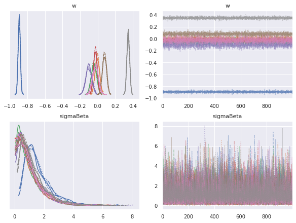

```python
az.plot_trace(inf_data_binom, compact=True, figsize=(8,6))
```

```
array([<AxesSubplot:title={'center':'95.0% HDI'}>], dtype=object)
```

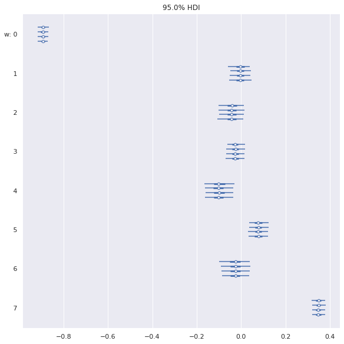

```python
az.plot_forest(inf_data_binom, var_names=['w'], hdi_prob=0.95, figsize=(8, 8))
```

Fit model and check significance of the parameters using HDI.

```python
summary = az.summary(inf_data_binom, round_to=2)
weights = summary.head(8)
weights = weights.set_index(x_scaled.columns)
weights = weights[weights['hdi_3%']*weights['hdi_97%']>0]
print(weights)
predict_features = weights[weights['hdi_3%']>=0.1].index
print(predict_features)
predict_features = predict_features.append(weights[weights['hdi_97%']<=-0.1].index)
print(predict_features)
predict_features = predict_features.values.tolist()
predict_features.remove('Intercept')
```

```
                mean    sd  hdi_3%  hdi_97%  mcse_mean  mcse_sd  ess_bulk  \
Intercept      -0.89  0.01   -0.92    -0.87        0.0      0.0   7990.59
confirmed      -0.10  0.03   -0.16    -0.03        0.0      0.0   3617.24
deaths          0.08  0.02    0.04     0.12        0.0      0.0   6077.18
ICUAvailPctAvg  0.35  0.02    0.32     0.38        0.0      0.0   4447.37

                ess_tail  r_hat
Intercept        2371.56   1.00
confirmed        3067.43   1.01
deaths           3045.47   1.00
ICUAvailPctAvg   3391.18   1.00
Index(['ICUAvailPctAvg'], dtype='object')
Index(['ICUAvailPctAvg', 'Intercept'], dtype='object')
```

```python
predict_features
```

```
['ICUAvailPctAvg']
```

Among all the features, 'confirmed' negatively associate with ICU availability. 'deaths' and 'ICUAvailPctAvg' are positively associate with ICU availability. However, the coefficient for confirmed and deaths is close to 0. ICUAvailPctAvg is the only predictor for the binomial regression.

Rescale weights for unscaled data

```python
weights = summary.head(8)
X_weights = weights['mean'][1:].values
Xsd = x_scales
Xmean = x_means
X_beta = X_weights/Xsd
beta0 = weights['mean'][0] - sum(X_beta*Xmean)
```

```python
feature_beta = pd.DataFrame(X_beta, index=X_test.columns,columns=['coefficient'])
feature_beta = feature_beta[feature_beta.index.isin(predict_features)]
```

```python
feature_beta
```

|  | coefficient |
| --- | --- |
| ICUAvailPctAvg | 4.155751 |

#### Predict ICU bed for test dataset

```python
X_feature = X_test[predict_features]
linPredICU = np.dot(X_feature,feature_beta)+beta0
linPredICU = [item for sublist in linPredICU for item in sublist]
pICU = np.exp(linPredICU)/(1+np.exp(linPredICU))
X_test.reset_index(inplace=True)
dataset = X_test[['ReportDate']]
dataset['y_hat'] = pICU
dataset['y'] = y_test.values/100
testset=dataset.set_index('ReportDate')
testset.head()
```

| ReportDate | y_hat | y |
| --- | --- | --- |
| 2020-06-24 | 0.463052 | 0.44 |
| 2020-07-07 | 0.463377 | 0.45 |
| 2020-11-04 | 0.334665 | 0.30 |
| 2021-01-22 | 0.271803 | 0.27 |
| 2021-06-11 | 0.253810 | 0.28 |

#### Evaluation model with MSE

MSE of test dataset

```python
mean_squared_error(y_test/100,pICU)
```

```
0.0012181783347598116
```

```python
r2_score(pICU,y_test/100,)
```

```
0.8201853526223932
```

Predict ICU availability for train dataset and evaluation model with MSE

```python
X_feature = X_train[predict_features]
linPredICU = np.dot(X_feature,feature_beta)+beta0
linPredICU = [item for sublist in linPredICU for item in sublist]
pICU = np.exp(linPredICU)/(1+np.exp(linPredICU))
X_train.reset_index(inplace=True)
dataset = X_train[['ReportDate']]
dataset['y_hat'] = pICU
dataset['y'] = y_train.values/100
trainset=dataset.set_index('ReportDate')
trainset.head()
```

| ReportDate | y_hat | y |
| --- | --- | --- |
| 2021-05-23 | 0.244750 | 0.25 |
| 2021-06-14 | 0.260306 | 0.28 |
| 2021-07-25 | 0.250847 | 0.21 |
| 2021-06-04 | 0.269221 | 0.26 |
| 2021-01-20 | 0.269994 | 0.27 |

MSE of train dataset

```python
mean_squared_error(pICU,y_train/100)
```

```
0.0009900762378566403
```

```python
r2_score(pICU,y_train/100)
```

```
0.8332741797476093
```

MSE for train and test data is similar, there is no over-fitting or under-fitting issue observed from comparing the MSE.

#### Plot ICU availability

```python
def icu_plot(ax,data,color):
    ax.vlines(
        x=data.index,
        ymin=0,
        ymax=data['y'],
        color="darkgrey",
        alpha=0.5,
        linewidth=1.5,
        label= "ICU bed availability",
    )

    ax.scatter(
        data.index,
        data['y_hat'],
        lw=2,
        color=color,
        s = 1.5,
        label="Predicted ICU bed availability",
    )

    ax.set_title(
        "ICU bed availability prediction",
        size=14,
    )
    ax.tick_params(axis='x', labelrotation = 45)
    ax.grid(axis="y", alpha=0.3)
    ax.legend(loc="lower left")
    ax.set_xlabel("Date", size=12)
    ax.set_ylabel("ICU bed availability", size=11)
```

Average percentage ICU percentage for trainset

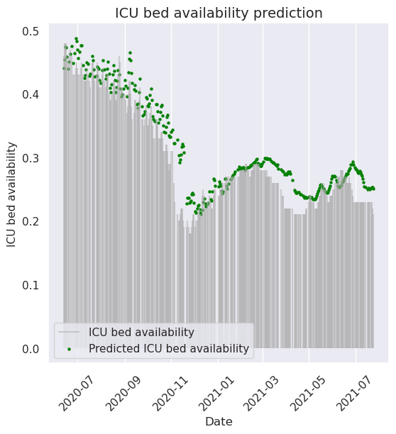

```python
fig, axs = plt.subplots(nrows=1, ncols=1,figsize=(6, 6), dpi=100)
plt.subplots_adjust(left=0.1,
                    bottom=0.1,
                    right=0.9,
                    top=0.9,
                    wspace=0.4,
                    hspace=0.4)

icu_plot(axs,trainset,"green")
```

Average percentage ICU percentage for testset

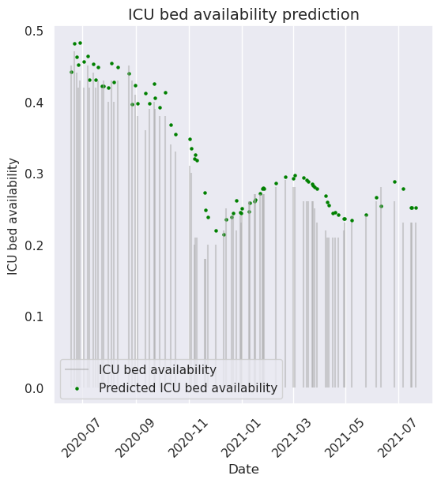

```python
fig, axs = plt.subplots(nrows=1, ncols=1,figsize=(6, 6), dpi=100)
plt.subplots_adjust(left=0.1,
                    bottom=0.1,
                    right=0.9,
                    top=0.9,
                    wspace=0.4,
                    hspace=0.4)

icu_plot(axs,testset,"green")
```

- The MSE and R2 score is similar comparing training and testing dataset.
- About 80% of the variance is explained by the model.
- It's clear that although the model predict the output well, there is a latency between prediction and the actual value.
- Next, we'll use this model for next 14 days ICU bed availability forecast.

```python
predict_data = merged_dataset.tail(14)
```

```python
X_feature = predict_data[predict_features]
linPredICU = np.dot(X_feature,feature_beta)+beta0
linPredICU = [item for sublist in linPredICU for item in sublist]
pICU = np.exp(linPredICU)/(1+np.exp(linPredICU))
predict_data.reset_index(inplace=True)
dataset = predict_data[['ReportDate']]
dataset['y_forecast'] = pICU
dataset=dataset.set_index('ReportDate')
dataset.head()
```

| ReportDate | y_forecast |
| --- | --- |
| 2021-07-26 | 0.251832 |
| 2021-07-27 | 0.251832 |
| 2021-07-28 | 0.252325 |
| 2021-07-29 | 0.253067 |
| 2021-07-30 | 0.251586 |

```python
def forecast_plot(ax,data,lower, upper,dates):
    ax.scatter(
        dates,
        data['y_forecast'],
        lw=2,
        color="green",
        s = 1.5,
        label="Forecasted ICU bed availability",
    )
    ax.fill_between(dates, y1=lower, y2=upper, color="blue", edgecolor="grey",alpha=0.1)
    ax.plot(dates, data['y_forecast'])
    ax.set_title(
        "percentage ICU bed availability 14 days forecast",
        size=14,
    )
    ax.tick_params(axis='x', labelrotation = 45)
    ax.grid(axis="y", alpha=0.3)
    ax.legend(loc="upper right")
    ax.set_xlabel("Date", size=12)
    ax.set_ylabel("ICU bed availability", size=11)
```

```python
def confint(count):
    lower,upper = proportion_confint(count,100,0.95)
    return (lower, upper)
```

```python
dates = pd.date_range(dataset.index[-1], periods=14).tolist()
```

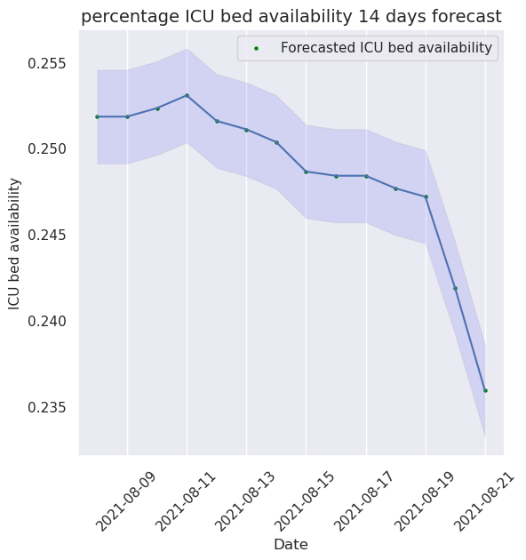

```python
fig, axs = plt.subplots(nrows=1, ncols=1,figsize=(6, 6), dpi=100)
plt.subplots_adjust(left=0.1,
                    bottom=0.1,
                    right=0.9,
                    top=0.9,
                    wspace=0.4,
                    hspace=0.4)
lower = [confint(x*100)[0] for x in dataset['y_forecast']]
upper = [confint(x*100)[1] for x in dataset['y_forecast']]
forecast_plot(axs,dataset,lower,upper,dates)
```

Since the model is not highly accurate, and the prediction percentage availability is not close to 20%, We will apply other model on this time series data

#### Time Series data exploration

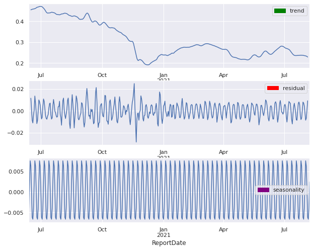

```python
series = merged_dataset[['ICUAvailPctAvg']]
res = seasonal_decompose(series, model='additive')
fig, (ax1,ax2,ax3) = plt.subplots(3,1, figsize=(10,8))

red_patch = mpatches.Patch(color='green', label='trend')
green_patch = mpatches.Patch(color='red', label='residual')
purple_patch = mpatches.Patch(color='purple', label='seasonality')
res.trend.plot(ax=ax1)
res.resid.plot(ax=ax2)
res.seasonal.plot(ax=ax3)
ax1.legend(handles=[red_patch])
ax2.legend(handles=[green_patch])
ax3.legend(handles=[purple_patch])
```

- There is an obvious trend in the time series data. The Percentage ICU bed availability dropped dramatically in the first 6 months, and fluctuates between 20%-30% from then on.
- KPSS test will be performed on the time series data to test the stationary of the time series data.

```python
X = series.values
kpss(X,nlags='auto')
```

```
(2.420378489955758,
 0.01,
 12,
 {'10%': 0.347, '5%': 0.463, '2.5%': 0.574, '1%': 0.739})
```

The p-value for KPSS test is less than 0.01. The time series data is non-stationary. 1 lag difference will be applied on this time series data

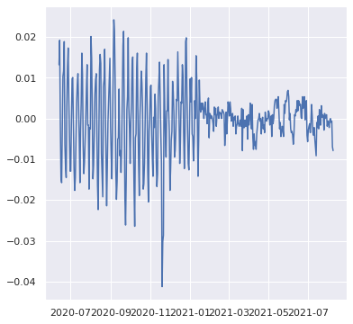

```python
plt.rcParams["figure.figsize"] = (6,6)
diff = series.diff()
plt.plot(diff)
```

```python
kpss(diff[1:],nlags='auto')
```

```
(0.1074825107036116,
 0.1,
 18,
 {'10%': 0.347, '5%': 0.463, '2.5%': 0.574, '1%': 0.739})
```

The KPSS P-value is greater than 0.1, indicating that the 1-lag difference data are stationary.

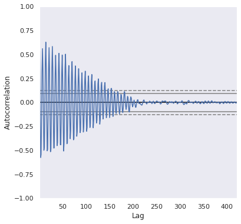

```python
autocorrelation_plot(diff[1:])
```

- The autocorrelation shows the time series has a surprisingly long memory. Even at 100 lags, the autocorrelation is significant. It's not appropriate to apply ARIMA or Var model for this time series data.
- Long short term memmory network is a special case of recurrent neural networks, capabale of modeling long dependencies. LSTM will be applied for modeling this time series data

#### LSTM model

```python
def standardize_df(df):
    """
    Standardize dataframe by column with mean=0 and std=1
    """
    scaler = preprocessing.StandardScaler()
    scaler = scaler.fit(df)
    df_scaled = scaler.transform(df)
    return scaler, df_scaled
```

```python
def construct_trainset(df,n_past,n_future):
    """
    construct train dataset with desired shape:
        n_sample * n_past * n_feature for trainX
        n_sample * 1 (n_future date) * feataure for trainY
    """
    trainX = []
    trainY = []

    for i in range(n_past,len(df)-n_future + 1):
        trainX.append(df[i-n_past:i,0:df.shape[1]])
        trainY.append(df[i+n_future-1:i+n_future,0].reshape(-1,1))
    trainX,trainY = np.array(trainX),np.array(trainY)
    return trainX, trainY
```

```python
def construct_predset(df,n_past,n_future):
    """
    Construct prediction dataset with desired shape:
        n_future*1*feature for predX
    """
    predX = []
    n_future =n_future
    n_past=n_past
    for i in range(len(df)-n_future-1,len(df)+1):
        predX.append(df[i-n_past:i,0:df.shape[1]])
    predX = np.array(predX)
    return predX
```

```python
def lstm_model(trainX,trainY):
    """
    Construct LSTM model with 1 LSTM layer, 1 Dropout layer and 1 fully connected layer
    Train model using gradient decent optimizer adam and evaluate loss function mse
    """
    model = Sequential()
    model.add(LSTM(64,activation='relu',input_shape=(trainX.shape[1],trainX.shape[2]),return_sequences=False))
    model.add(Dropout(0.2))
    model.add(Dense(trainY.shape[1]))
    model.compile(optimizer='adam',loss='mse')
    model.summary()
    return model
```

```python
def forecast(model,trainX,data,scaler):
    """
    Forecast y_pred from trainning data X_train
    """
    forecast = model.predict(trainX)
    forecast_copies = np.repeat(forecast,trainX.shape[2],axis=-1)
    y_pred_future = scaler.inverse_transform(forecast_copies)[:,0]
    return y_pred_future
```

```python
def timeseriessplit(series, blocks):
    """
    Create a list of blocking time series cross validation index for train and test data at each cross validation
    """
    tscv = TimeSeriesSplit(n_splits = blocks, test_size=14)
    return tscv.split(series)
```

```python
def crossvalidation(trainX,trainY,train_index,test_index,iterations, model, n_past, n_future,scaler,data_dates):
    """
    Perform cross validation for time series data
    Construct dataframe with y_pred and y
    y_pred is predicted with the LSTM model
    Construct dataframe with y_forecast
    y_forecast is predicted with the LSTM model forecasting 14 days after the last date of existing data
    Construct dictionary for CV evaluation
    """
    # Specify train and test data
    X_train,X_test = trainX[train_index], trainX[test_index]
    y_train,y_test = trainY[train_index], trainY[test_index]
    X_train_predicts = list()
    X_test_predicts = list()
    evaluation = dict()
    # Perform iterations on each crossvaliation and average the output for this stocastic process.
    for j in range(iterations):
        history = model.fit(X_train,y_train,epochs=100,verbose=0,batch_size = 128)
        X_train_predict=forecast(model,X_train,trainX,scaler)
        X_test_predict = forecast(model,X_test,trainX,scaler)

        X_train_predicts.append(X_train_predict)
        X_test_predicts.append(X_test_predict)
    # organize the predicted and actual ICU percentage
    X_train_predicts = np.array(X_train_predicts)
    X_train_predict = np.mean(X_train_predicts, axis=0)
    X_test_predicts = np.array(X_test_predicts)
    X_test_predict = np.mean(X_test_predicts, axis=0)

    y_train_copies = np.repeat(y_train,trainX.shape[2],axis=-1)
    y_train = scaler.inverse_transform(y_train_copies)[:,0]
    y_train = [x[0] for x in y_train]
    y_test_copies = np.repeat(y_test,trainX.shape[2],axis=-1)
    y_test = scaler.inverse_transform(y_test_copies)[:,0]
    y_test = [x[0] for x in y_test]

    # Calculate the dates for trainset
    init_train_index = n_future+n_past-1+train_index[0]
    end_train_index = n_future+n_past+train_index[-1]

    # Calculate the dates for testset
    init_test_index = n_future+n_past-1+test_index[0]
    end_test_index = n_future+n_past+test_index[-1]

    # Calcuate the evaluation matrix
    X_train_mse = mean_squared_error(y_train,X_train_predict)
    X_test_mse = mean_squared_error(y_test,X_test_predict)
   # X_train_r2 = r2_score(y_train,X_train_predict)
   # X_test_r2 = r2_score(y_test,X_test_predict)

    evaluation['train_mse'] = X_train_mse
    evaluation['test_mse'] = X_test_mse
  #  evaluation['train_r2'] = X_train_r2
  #  evaluation['test_r2'] = X_test_r2

    y_train_df = pd.DataFrame(list(zip(X_train_predict,y_train,data_dates[init_train_index:end_train_index])),columns=['y_hat','y','date']).set_index('date', drop=True)
    y_test_df = pd.DataFrame(list(zip(X_test_predict,y_test,data_dates[init_test_index:end_test_index])),columns=['y_hat','y','date']).set_index('date', drop=True)

    return y_train_df, y_test_df, evaluation
```

#### Univariate time series forecasting using LSTM model

```python
def lstm_pred(data, n_past, n_future,blocks,iterations):
    """
    Construct dataframe with y_pred and y
    y_pred is predicted with the LSTM model
    Construct dataframe with y_forecast
    y_forecast is predicted with the LSTM model forecasting 14 days after the last date of existing data
    """
    data_dates = pd.to_datetime(data.index)
    data_series = data['ICUAvailPctAvg'].values.reshape(-1,1)
    scaler, data_series_scaled = standardize_df(data_series)

    trainX,trainY = construct_trainset(data_series_scaled,30,14)
    predX = construct_predset(data_series_scaled,n_past,n_future)

    cvs = list(timeseriessplit(trainX, blocks))

    model = lstm_model(trainX,trainY)

    fig, axs = plt.subplots(nrows=4, ncols=2,figsize=(18, 30), dpi=100)
    plt.subplots_adjust(left=0.1,
                    bottom=0.1,
                    right=0.9,
                    top=0.9,
                    wspace=0.4,
                    hspace=0.4)
    i = 0
   # for train_index, test_index in tscv.split(trainX):
    evaluations = list()
    for ax in axs.reshape(-1):
        train_index,test_index = cvs[i]
        y_train_df, y_test_df, evaluation = crossvalidation(trainX,trainY,train_index,test_index,iterations, model, n_past, n_future,scaler,data_dates)
        icu_plot(ax,y_train_df,"green")
        icu_plot(ax,y_test_df,"purple")
        i = i+1
        evaluations.append(evaluation)
    plt.show()
    evaluation_df = pd.DataFrame(evaluations)
    return(evaluation_df)
```

Predict, forecast and plot predicted Pct ICU availability/Pct ICU availability across time

```
Model: "sequential"
_________________________________________________________________
Layer (type)                 Output Shape              Param #
=================================================================
lstm (LSTM)                  (None, 64)                16896
_________________________________________________________________
dropout (Dropout)            (None, 64)                0
_________________________________________________________________
dense (Dense)                (None, 1)                 65
=================================================================
Total params: 16,961
Trainable params: 16,961
Non-trainable params: 0
_________________________________________________________________
```

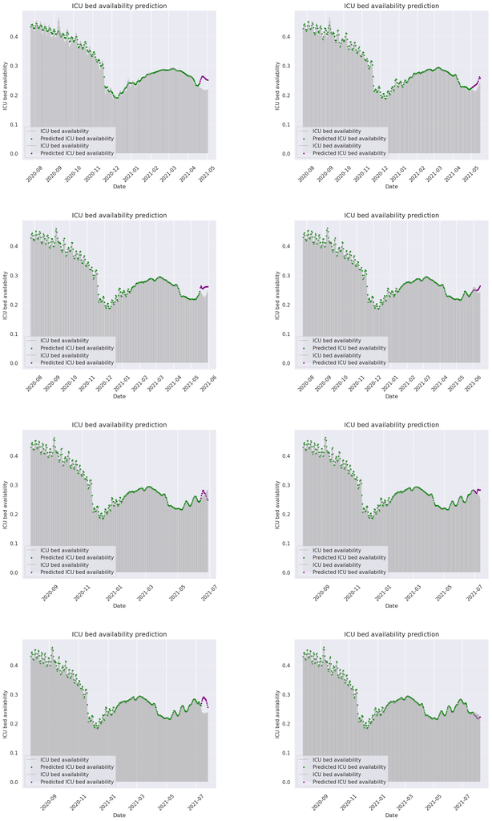

```python
evaluation_df = lstm_pred(merged_dataset,30,14,8,20)
```

```python
evaluation_df
```

|  | train_mse | test_mse |
| --- | --- | --- |
| 0 | 0.000081 | 0.001322 |
| 1 | 0.000018 | 0.000327 |
| 2 | 0.000005 | 0.000625 |
| 3 | 0.000003 | 0.000137 |
| 4 | 0.000003 | 0.000347 |
| 5 | 0.000002 | 0.000163 |
| 6 | 0.000002 | 0.001848 |
| 7 | 0.000002 | 0.000142 |

#### Multivariate time series forecasting using LSTM model

```python
def multivar_lstm_pred(data, n_past, n_future,blocks, iterations):
    """
    Construct dataframe with y_pred and y
    y_pred is predicted with the LSTM model
    Construct dataframe with y_forecast
    y_forecast is predicted with the LSTM model forecasting 14 days after the last date of existing data
    """
    data_dates = pd.to_datetime(data.index)
    cols = ['ICUAvailPctAvg','confirmed', 'deaths', 'parks', 'transit', 'residential','CLIAdmissions_RollingAvg']
    data_series = data[cols].astype(float).values.reshape(len(data),len(cols))
    scaler, data_series_scaled = standardize_df(data_series)

    trainX,trainY = construct_trainset(data_series_scaled,n_past,n_future)
    predX = construct_predset(data_series_scaled,n_past,n_future)

    cvs = list(timeseriessplit(trainX, blocks))

    model = lstm_model(trainX,trainY)

    fig, axs = plt.subplots(nrows=4, ncols=2,figsize=(18, 30), dpi=100)
    plt.subplots_adjust(left=0.1,
                    bottom=0.1,
                    right=0.9,
                    top=0.9,
                    wspace=0.4,
                    hspace=0.4)
    i = 0
   # for train_index, test_index in tscv.split(trainX):
    evaluations = list()
    for ax in axs.reshape(-1):
        train_index,test_index = cvs[i]
        y_train_df, y_test_df, evaluation = crossvalidation(trainX,trainY,train_index,test_index,iterations, model, n_past, n_future,scaler,data_dates)
        icu_plot(ax,y_train_df,"green")
        icu_plot(ax,y_test_df,"purple")
        i = i+1
        evaluations.append(evaluation)
    plt.show()
    evaluation_df = pd.DataFrame(evaluations)
    return(evaluation_df)
```

```
Model: "sequential_1"
_________________________________________________________________
Layer (type)                 Output Shape              Param #
=================================================================
lstm_1 (LSTM)                (None, 64)                18432
_________________________________________________________________
dropout_1 (Dropout)          (None, 64)                0
_________________________________________________________________
dense_1 (Dense)              (None, 1)                 65
=================================================================
Total params: 18,497
Trainable params: 18,497
Non-trainable params: 0
_________________________________________________________________
```

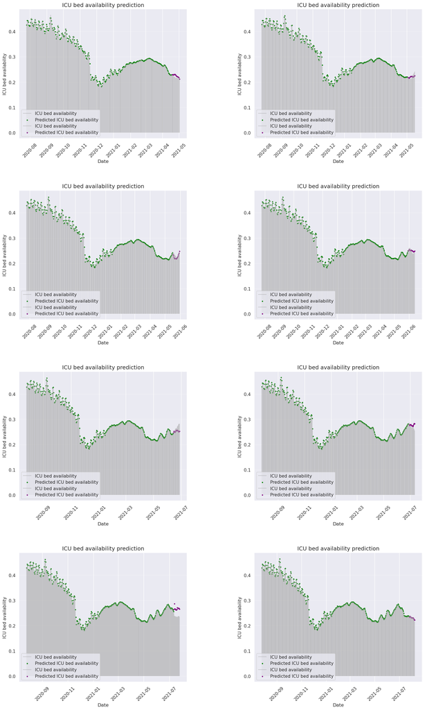

```python
evaluation_df = multivar_lstm_pred(merged_dataset,30,14,8,20)
```

```python
evaluation_df
```

|  | train_mse | test_mse |
| --- | --- | --- |
| 0 | 1.568987e-05 | 0.000049 |
| 1 | 4.828908e-06 | 0.000068 |
| 2 | 3.047951e-06 | 0.000093 |
| 3 | 2.164136e-06 | 0.000043 |
| 4 | 1.570045e-06 | 0.000309 |
| 5 | 7.228912e-07 | 0.000141 |
| 6 | 9.459476e-07 | 0.000959 |
| 7 | 8.420228e-07 | 0.000012 |

#### CNN-LSTM model

A convolutional neural network, or CNN, can be used as the encoder in an encoder-decoder architecture.

The CNN does not directly support sequence input; instead, a 1D CNN is capable of reading across sequence input and automatically learning the salient features. These can then be interpreted by an LSTM decoder as per normal. We refer to hybrid models that use a CNN and LSTM as CNN-LSTM models, and in this case we are using them together in an encoder-decoder architecture.

```python
def cnn_lstm_model(trainX,trainY):
    """
    Construct CNN-LSTM encoder-decoder archetecture with 1D Convolution layer, maxpooling layer,
    flatten layer, decoder LSTM layer, Dropout layer and  timedistributed layer.
    Train model using gradient decent optimizer adam and evaluate loss function mse
    """
    model = Sequential()
    model.add(Conv1D(filters=64, kernel_size=3, activation='relu', input_shape=(trainX.shape[1],trainX.shape[2])))
    model.add(MaxPooling1D(pool_size=2))
    model.add(Flatten())
    model.add(RepeatVector(trainY.shape[2]))
    model.add(LSTM(200, activation='relu', return_sequences=True))
    model.add(Dropout(0.2))
    model.add(TimeDistributed(Dense(1)))
    model.compile(optimizer='adam',loss='mse')
    model.summary()
    return model
```

#### Univariate time series forecasting using CNN-LSTM model

```python
def cnn_lstm_pred(data, n_past, n_future,blocks, iterations):
    """
    Construct dataframe with y_pred and y
    y_pred is predicted with the LSTM model
    Construct dataframe with y_forecast
    y_forecast is predicted with the LSTM model forecasting 14 days after the last date of existing data
    """
    data_dates = pd.to_datetime(data.index)
    data_series = data['ICUAvailPctAvg'].values.reshape(-1,1)
    scaler, data_series_scaled = standardize_df(data_series)

    trainX,trainY = construct_trainset(data_series_scaled,n_past,n_future)
    predX = construct_predset(data_series_scaled,n_past,n_future)

    cvs = list(timeseriessplit(trainX, blocks))

    model = cnn_lstm_model(trainX,trainY)

    fig, axs = plt.subplots(nrows=4, ncols=2,figsize=(18, 30), dpi=100)
    plt.subplots_adjust(left=0.1,
                    bottom=0.1,
                    right=0.9,
                    top=0.9,
                    wspace=0.4,
                    hspace=0.4)
    i = 0
   # for train_index, test_index in tscv.split(trainX):
    evaluations = list()
    for ax in axs.reshape(-1):
        train_index,test_index = cvs[i]
        y_train_df, y_test_df, evaluation = crossvalidation(trainX,trainY,train_index,test_index,iterations, model, n_past, n_future,scaler,data_dates)
        icu_plot(ax,y_train_df,"green")
        icu_plot(ax,y_test_df,"purple")
        i = i+1
        evaluations.append(evaluation)
    plt.show()
    evaluation_df = pd.DataFrame(evaluations)
    return(evaluation_df)
```

```
Model: "sequential_2"
_________________________________________________________________
Layer (type)                 Output Shape              Param #
=================================================================
conv1d (Conv1D)              (None, 28, 64)            256
_________________________________________________________________
max_pooling1d (MaxPooling1D) (None, 14, 64)            0
_________________________________________________________________
flatten (Flatten)            (None, 896)               0
_________________________________________________________________
repeat_vector (RepeatVector) (None, 1, 896)            0
_________________________________________________________________
lstm_2 (LSTM)                (None, 1, 200)            877600
_________________________________________________________________
dropout_2 (Dropout)          (None, 1, 200)            0
_________________________________________________________________
time_distributed (TimeDistri (None, 1, 1)              201
=================================================================
Total params: 878,057
Trainable params: 878,057
Non-trainable params: 0
_________________________________________________________________
```

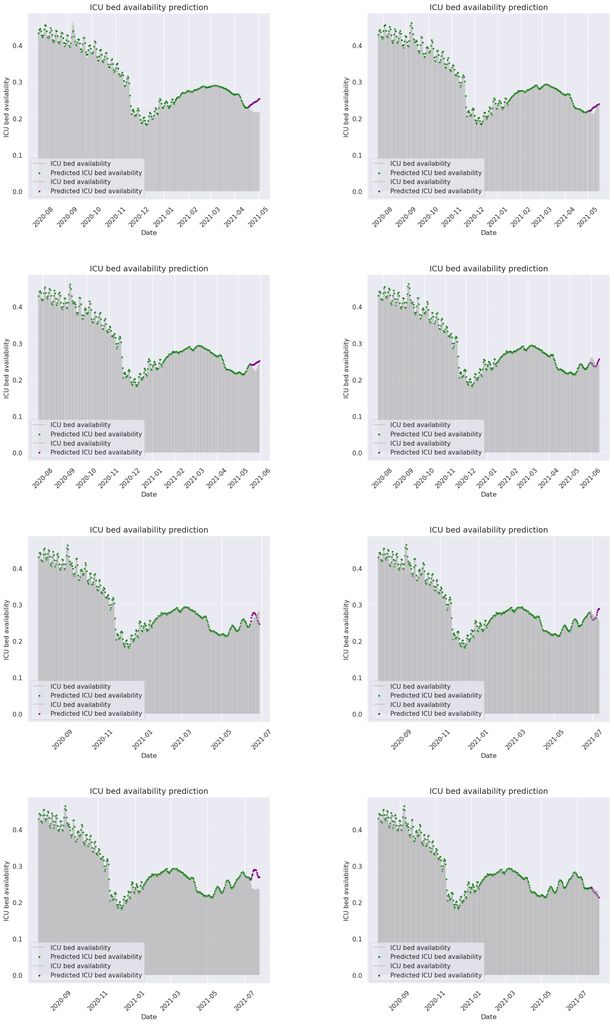

|  | train_mse | test_mse |
| --- | --- | --- |
| 0 | 2.223913e-05 | 0.000646 |
| 1 | 2.286100e-06 | 0.000104 |
| 2 | 1.311110e-06 | 0.000149 |
| 3 | 1.095551e-06 | 0.000160 |
| 4 | 6.126649e-07 | 0.000362 |
| 5 | 8.083869e-07 | 0.000283 |
| 6 | 6.975940e-07 | 0.001892 |
| 7 | 8.629335e-07 | 0.000072 |

```python
cnn_lstm_pred(merged_dataset,30,14,8,20)
```

```python
def forecast(model,trainX,data,scaler):
    """
    Forecast y_pred from trainning data X_train
    """
    forecast = model.predict(trainX)
    forecast_copies = np.repeat(forecast,trainX.shape[2],axis=-1)
    y_pred_future = scaler.inverse_transform(forecast_copies)[:,0,0]
    return y_pred_future
```

#### Multivariate time series forecasting using CNN-LSTM model

```python
def multivar_cnn_lstm_pred(data, n_past, n_future,blocks, iterations):
    """
    Construct dataframe with y_pred and y
    y_pred is predicted with the LSTM model
    Construct dataframe with y_forecast
    y_forecast is predicted with the LSTM model forecasting 14 days after the last date of existing data
    """
    data_dates = pd.to_datetime(data.index)
    cols = ['ICUAvailPctAvg','confirmed', 'deaths', 'parks', 'transit', 'residential','CLIAdmissions_RollingAvg']
    data_series = data[cols].astype(float).values.reshape(len(data),len(cols))
    scaler, data_series_scaled = standardize_df(data_series)

    trainX,trainY = construct_trainset(data_series_scaled,n_past,n_future)
    predX = construct_predset(data_series_scaled,n_past,n_future)

    cvs = list(timeseriessplit(trainX, blocks))

    model = cnn_lstm_model(trainX,trainY)

    fig, axs = plt.subplots(nrows=4, ncols=2,figsize=(18, 30), dpi=100)
    plt.subplots_adjust(left=0.1,
                    bottom=0.1,
                    right=0.9,
                    top=0.9,
                    wspace=0.4,
                    hspace=0.4)
    i = 0
   # for train_index, test_index in tscv.split(trainX):
    evaluations = list()
    for ax in axs.reshape(-1):
        train_index,test_index = cvs[i]
        y_train_df, y_test_df, evaluation = crossvalidation(trainX,trainY,train_index,test_index,iterations, model, n_past, n_future,scaler,data_dates)
        icu_plot(ax,y_train_df,"green")
        icu_plot(ax,y_test_df,"purple")
        i = i+1
        evaluations.append(evaluation)
    plt.show()
    evaluation_df = pd.DataFrame(evaluations)
    return(evaluation_df)
```

```
Model: "sequential_3"
_________________________________________________________________
Layer (type)                 Output Shape              Param #
=================================================================
conv1d_1 (Conv1D)            (None, 28, 64)            1408
_________________________________________________________________
max_pooling1d_1 (MaxPooling1 (None, 14, 64)            0
_________________________________________________________________
flatten_1 (Flatten)          (None, 896)               0
_________________________________________________________________
repeat_vector_1 (RepeatVecto (None, 1, 896)            0
_________________________________________________________________
lstm_3 (LSTM)                (None, 1, 200)            877600
_________________________________________________________________
dropout_3 (Dropout)          (None, 1, 200)            0
_________________________________________________________________
time_distributed_1 (TimeDist (None, 1, 1)              201
=================================================================
Total params: 879,209
Trainable params: 879,209
Non-trainable params: 0
_________________________________________________________________
```

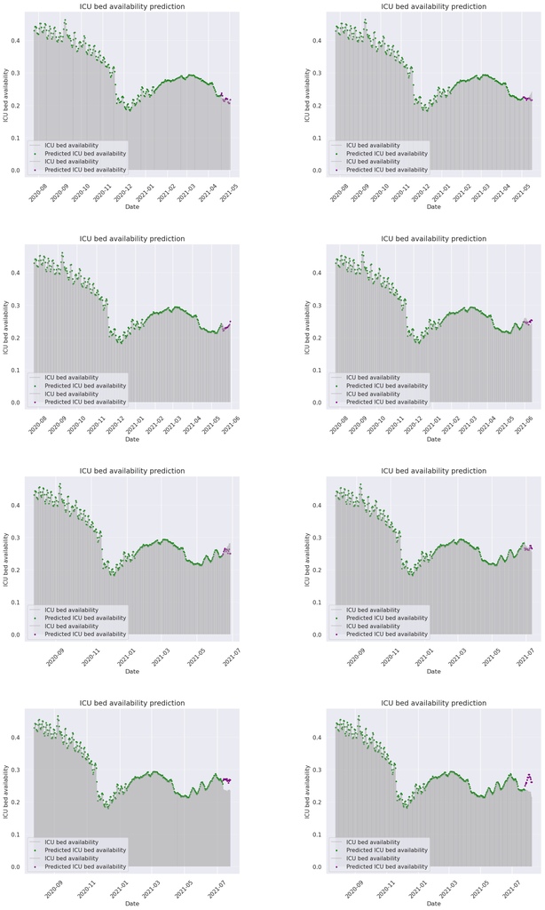

|  | train_mse | test_mse |
| --- | --- | --- |
| 0 | 1.073632e-06 | 0.000054 |
| 1 | 2.986577e-07 | 0.000132 |
| 2 | 7.173979e-07 | 0.000068 |
| 3 | 2.412671e-07 | 0.000105 |
| 4 | 1.102273e-07 | 0.000236 |
| 5 | 4.862276e-07 | 0.000125 |
| 6 | 9.505806e-08 | 0.000942 |
| 7 | 1.437767e-07 | 0.001429 |

```python
multivar_cnn_lstm_pred(merged_dataset,30,14,8,20)
```

- Univariate time series LSTM, multivariate time series LSTM, Univariate time series CNN-LSTM and multivariate time series CNN-LSTM models don't show systematic time lag compared to Bayesian regression model.
- By comparing MSE , multivariate time series LSTM model has the best performance.
- We will apply multivariate time series LSTM model to forecast the percentage ICU avaiability for the next 14 days.

```python
def forecast(model,trainX,data,scaler):
    """
    Forecast y_pred from trainning data X_train
    """
    forecast = model.predict(trainX)
    forecast_copies = np.repeat(forecast,trainX.shape[2],axis=-1)
    y_pred_future = scaler.inverse_transform(forecast_copies)[:,0]
    return y_pred_future
```

```python
def multivar_lstm_forecast(data):
    """
    Construct dataframe with y_pred and y
    y_pred is predicted with the LSTM model
    Construct dataframe with y_forecast
    y_forecast is predicted with the LSTM model forecasting 14 days after the last date of existing data
    """

    data_dates = pd.to_datetime(data.index)
    cols = ['ICUAvailPctAvg','confirmed', 'deaths', 'parks', 'transit', 'residential','CLIAdmissions_RollingAvg']
    data_series = data[cols].astype(float).values.reshape(len(data),len(cols))
    scalar, data_series_scaled = standardize_df(data_series)

    trainX,trainY = construct_trainset(data_series_scaled,30,14)
    X_train, y_train= trainX,trainY

    predX = construct_predset(data_series_scaled,30,14)

    y_forecasts = list()
    for j in range(20):
        model = lstm_model(X_train, y_train)
        history = model.fit(X_train, y_train,epochs=100,verbose=0)
        y_forecast = forecast(model,predX,data_series,scalar)
        y_forecasts.append(y_forecast)

    y_forecasts = np.array(y_forecasts)
    y_forecast = np.mean(y_forecasts, axis=0)

    y_forecast = y_forecast[:14]
    y_forecast_sd = np.std(y_forecast)


    lower = y_forecast-3*y_forecast_sd
    upper = y_forecast+3*y_forecast_sd

    dates = pd.date_range(data_dates[-1], periods=14).tolist()

    y_forecast_df = pd.DataFrame(list(zip(y_forecast,dates)),columns=['y_forecast','date']).set_index('date',drop=True)


    fig, axs = plt.subplots(nrows=1, ncols=1,figsize=(6, 6), dpi=100)
    plt.subplots_adjust(left=0.1,
                        bottom=0.1,
                        right=0.9,
                        top=0.9,
                        wspace=0.4,
                        hspace=0.4)

    forecast_plot(axs,y_forecast_df,lower,upper,dates)
```

[output not shown]

[output cut: 227 more lines]

```
_________________________________________________________________
Model: "sequential_23"
_________________________________________________________________
Layer (type)                 Output Shape              Param #
=================================================================
lstm_23 (LSTM)               (None, 64)                18432
_________________________________________________________________
dropout_23 (Dropout)         (None, 64)                0
_________________________________________________________________
dense_23 (Dense)             (None, 1)                 65
=================================================================
Total params: 18,497
Trainable params: 18,497
Non-trainable params: 0
_________________________________________________________________
```

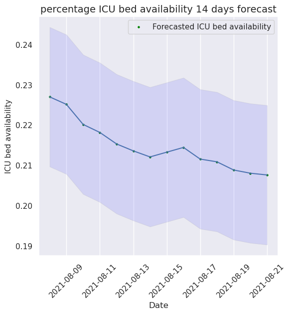

```python
multivar_lstm_forecast(merged_dataset)
```

The 14 days forecast from multivariate LSTM model shows there is a ICU bed availabiity shortage risk for Illinois.

#### Conclusion

Mean squared error(MSE) between predicted value and output is estimated to evaluate the model. The MSE for trainning and test data are similar and small, indicating the model doesn't have overfitting or underfitting issue. The model effectively predicted the ICU bed availability in 14 days. The predicted value and output for test data was visualized for comparison. It's clear that although the model predicts the output well, the trends of prediction and the output show a time lag. A model handling time series dataset is required.

We then applied univariate and multivariate time series LSTM model for predicting ICU bed availability in 14 days. The predicted percentage ICU bed availability shows no systematic time lag compared to actual percentage ICU bed availability. The multivariate LSTM has better performance than the Univariate model, the MSE is small.

We further constructed CNN-LSTM Ecoder-Decoder model for predicting ICU bed availability in 14 days. The CNN encoder is able to extract salient features and the LSTM decoder is able to construct a time series prediction. The CNN-LSTM model doesn't perform better with the test data compared to LSTM model, maybe due to overfitting the model with the trainning dataset. Multivariate LSTM model is applied to forecast percentage ICU availability in 14 days from the last day of our dataset.

The forecasted result shows there is a risk that percentage ICU availability could drop below 20% in near future. There is concern that Illinois will face ICU bed availability shortage.